# An overview of package plot3logit

Flavio Santi, Maria Michela Dickson, Giuseppe Espa, Diego Giuliani

2025-12-16

## Introduction

The package permits the covariate effects of trinomial regression models to be represented graphically by means of a ternary plot. The aim of the plots is helping the interpretation of regression coefficients in terms of the effects that a change in regressors’ values has on the probability distribution of the dependent variable. Such changes may involve either a single regressor, or a group of them (composite changes), and the package permits both cases to be handled in a user-friendly way. Methodological details are illustrated and discussed in Santi, Dickson, and Espa (2019).

The package can read the results of **both categorical and ordinal trinomial logit** regression fitted by various functions (see the next section) and creates a `field3logit` object which may be represented by means of functions `gg3logit` and `stat_field3logit`.

The `plot3logit` package inherits graphical classes and methods from the package `ggtern` (Hamilton and Ferry 2018) which, in turn, is based on the package `ggplot2` (Wickham 2016).

Graphical representation based on **standard graphics** is made available through the package `Ternary` (Smith 2017) by functions `plot3logit` and `TernaryField`, and by the `plot` method of `field3logit` objects.

See the help of `field3logit` for representing composite effects and `multifield3logit` for drawing multiple fields.

See Santi et al. (2022) for a detailed presentation of the package and its features, or read the main vignette of the package which is based on it.

## Compatibility

Function `field3logit` of package `plot3logit` can read trinomial regression estimates from the output of the following functions:

- `polr` of package `MASS` (ordinal logit regression);
- `mlogit` of package `mlogit` (logit regression);
- `multinom` of package `nnet` (logit regression);
- `clm` and `clm2` of package `ordinal` (ordinal logit regression);
- `vgam` and `vglm` of package `VGAM` (logit regression).

Explicit estimates can be passed to `field3logit()` by means of a named list too (see the help of `field3logit` or the main vignette of the package); moreover, users can easily extend the range of objects that can be processed by `field3logit()` by implementing the S3 methods of the generic `extract3logit` (see the help).

In the following, an example is provided for each object `field3logit` can work with. First, however, package `plot3logit` must be attached and dataset `cross_1year` must be loaded:

```r
library(plot3logit)
data(cross_1year)
str(cross_1year)
```

```
#> 'data.frame':    3282 obs. of  7 variables:
#>  $ employment_sit: Factor w/ 3 levels "Employed","Unemployed",..: 1 1 1 3 1 1 1 1 1 2 ...
#>  $ gender        : Factor w/ 2 levels "Male","Female": 2 1 2 2 2 1 2 1 1 2 ...
#>  $ finalgrade    : Factor w/ 3 levels "Average","Low",..: 3 3 1 1 2 3 1 1 2 3 ...
#>  $ duration      : Factor w/ 3 levels "Average","Short",..: 3 3 3 3 3 3 1 3 3 3 ...
#>  $ social_class  : Factor w/ 5 levels "Working class",..: 1 2 4 4 3 3 1 4 1 2 ...
#>  $ irregularity  : Factor w/ 3 levels "Average","Low",..: 1 1 3 3 3 3 1 3 3 3 ...
#>  $ hsscore       : num  100 95 82 64 69 ...
```

### Package `MASS`

Function `polr` of package `MASS` (Venables and Ripley 2002) fits a *proportional odds logistic regression* by means of a fairly simple syntax, however the order of labels of the dependent variable must be explicitly stated:

```r
library(MASS)

mydata <- cross_1year
mydata$finalgrade <- factor(
  x = mydata$finalgrade,
  levels = c('Low', 'Average', 'High'),
  ordered = TRUE
)

mod0 <- polr(finalgrade ~ gender + irregularity, data = mydata)
field3logit(mod0, 'genderFemale')
```

### Package `mlogit`

Package `mlogit` of package `mlogit` (Croissant 2020) can fit a wide range of models. The current implementation of `plot3logit` only works with pure trinomial models, where only specific coefficients are considered:

```r
library(mlogit)
mydata <- mlogit.data(cross_1year, choice = 'employment_sit', shape = 'wide')
mod0 <- mlogit(employment_sit ~ 0 | gender + finalgrade, data = mydata)
field3logit(mod0, 'genderFemale')
```

### Package `nnet`

Function `multinom` of package `nnet` (Venables and Ripley 2002) fits a multinomial model by means of a very simple syntax:

```r
library(nnet)
mod0 <- multinom(employment_sit ~ gender + finalgrade, data = cross_1year)
field3logit(mod0, 'genderFemale')
```

### Package `ordinal`

```r
library(ordinal)

mydata$finalgrade <- factor(mydata$finalgrade, c('Low', 'Average', 'High'))

mod0 <- clm(finalgrade ~ gender + irregularity, data = mydata)
field3logit(mod0, 'genderFemale')

mod0 <- clm2(finalgrade ~ gender + irregularity, data = mydata)
field3logit(mod0, 'genderFemale')
```

### Package `VGAM`

Package `VGAM` (Yee 2010) permits multinomial logistic models to be fitted by means of two functions: `vgam` and `vglm`. In case of multinomial logistic models they share the same syntax:

```r
library(VGAM)

mod0 <- vgam(
  formula = employment_sit ~ gender + finalgrade,
  family = multinomial(),
  data = cross_1year
)
field3logit(mod0, 'genderFemale')

mod0 <- vglm(
  formula = employment_sit ~ gender + finalgrade,
  family = multinomial(),
  data = cross_1year
)
field3logit(mod0, 'genderFemale')
```

### Reading from `list`

Point estimates and other information on a fitted model may be passed as a named list to `field3logit`. In case of a non-ordinal trinomial model, the matrix of coefficients (component `B`) should be a matrix with named rows and two columns, whereas possible levels of the dependent variable should be included as a separate component (`levels`) which should be a character vector of length three, whose first component is the reference level of the model (see the help of `extract3logit` for details):

```r
mod0 <- list(
  B = matrix(
    data = c(-2.05, 0.46, -2.46, 0.37, -1.2, 0.8, 0.7, 0.4),
    ncol = 2,
    dimnames = list(c('Intercept', 'X1', 'X2', 'X3'))
  ),
  levels = c('Class A', 'Class B', 'Class C')
)
field3logit(mod0, 'X1')
```

## A brief example

Fit a trilogit model by means of package `nnet` where the student’s employment situation is analysed with respect to all variables in the dataset `cross_1year`:

```r
library(plot3logit)
data(cross_1year)
library(nnet)
mod0 <- multinom(employment_sit ~ ., data = cross_1year)
```

The gender effect is analysed by means of a ternary plot which is generated in two steps.

Firstly, the vector field is computed:

```r
field0 <- field3logit(mod0, 'genderFemale')
```

Secondly, the field is represented on a ternary plot, using either `gg`-graphics:

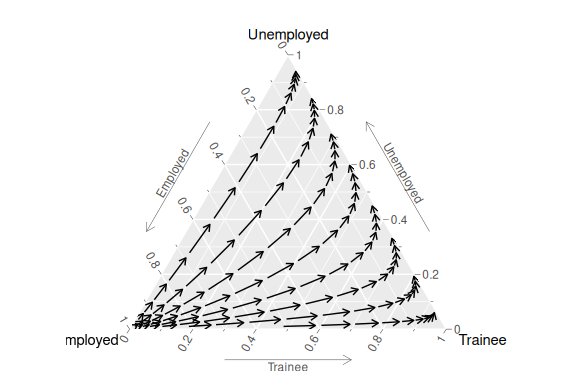

```r
gg3logit(field0) + stat_field3logit()
```

or standard graphics:

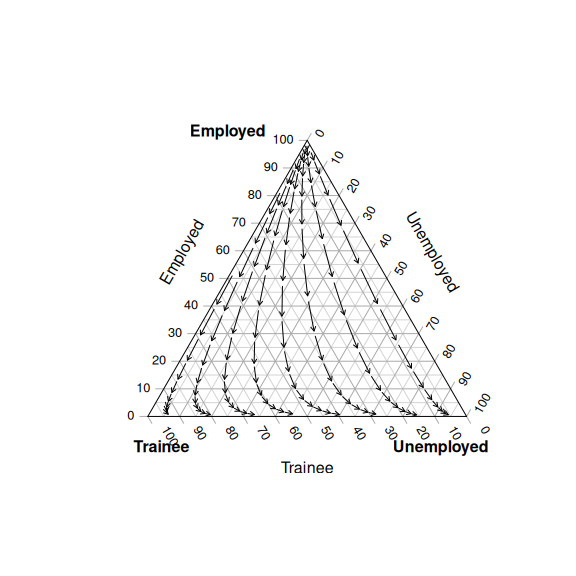

```r
plot(field0)
```

## How to specify the covariate changes

Ternary plots represent the effect of a change in covariate values on the probability distribution of the dependent variable. The function `field3logit` permits such change to be specified in three different ways: explicitly, as a numeric vector, or implicitly, either by means of a named numeric vector, or by means of an R expressions. All three methods are briefly illustrated below.

As an example, the following subsections refer to this trinomial logistic regression model:

```r
library(plot3logit)
library(nnet)
mod0 <- multinom(employment_sit ~ finalgrade + irregularity + hsscore, cross_1year)
mod0
```

```
#> Call:
#> multinom(formula = employment_sit ~ finalgrade + irregularity +
#>     hsscore, data = cross_1year)
#>
#> Coefficients:
#>            (Intercept) finalgradeLow finalgradeHigh irregularityLow
#> Unemployed  -0.4481761    0.05551765    -0.07810893     -0.01874354
#> Trainee     -1.3751140    0.14456683    -0.26849829      0.05764144
#>            irregularityHigh      hsscore
#> Unemployed       0.15691595 -0.016619227
#> Trainee         -0.03477569 -0.009964381
#>
#> Residual Deviance: 4314.176
#> AIC: 4338.176
```

### Explicit specification of $\Delta x$

This method for specifying the change in the covariate values requires the vector $\Delta x$ to be explicitly defined, thus it may be suitable when $\Delta x$ results from some calculations. On the other hand, it is less user-friendly than implicit syntax, as it depends on the order of regressors in the design matrix.

#### First example

If the effect of a *high final grade* has to be assessed, the vector of changes $\Delta x$ can be set according to the position of the dummy variable `finalgradeHigh` in the matrix of coefficients of the model `mod0`:

```r
coef(mod0)
```

```
#>            (Intercept) finalgradeLow finalgradeHigh irregularityLow
#> Unemployed  -0.4481761    0.05551765    -0.07810893     -0.01874354
#> Trainee     -1.3751140    0.14456683    -0.26849829      0.05764144
#>            irregularityHigh      hsscore
#> Unemployed       0.15691595 -0.016619227
#> Trainee         -0.03477569 -0.009964381
```

It follows that the function `field3logit` can be invoked as it follows:

```r
field3logit(mod0, c(0, 0, 1, 0, 0, 0))
```

```
#>  Object of class "field3logit"
#> -------------------------------
#> Label                    : <empty>
#> Possible outcomes        : Employed; Unemployed; Trainee
#> Reference level          : Employed
#> Type of model            : categorical
#> Effect                   : 0 0 1 0 0 0
#> Model has been read from : nnet::multinom
#> Number of stream lines   : 8
#> Number of arrows         : 182
#> Covariance matrix        : available
#> Confidence regions       : not available
```

#### Second example

It is also possible to set $\Delta x$ so as to consider changes involving more than one regressor, as well as fractional changes. In such cases, $\Delta x$ will consist in a vector where there are several non-zero elements which may take any positive or negative value.

Assume, for example, that we want to study the effect of a decrease by 10 in the high school final score, associated to an high final grade. In such a case, we have that:
$$\Delta x =[0, 0, 1, 0, 0, -10]'\,,$$
thus:

```r
field3logit(mod0, c(0, 0, 1, 0, 0, -10))
```

```
#>  Object of class "field3logit"
#> -------------------------------
#> Label                    : <empty>
#> Possible outcomes        : Employed; Unemployed; Trainee
#> Reference level          : Employed
#> Type of model            : categorical
#> Effect                   : 0 0 1 0 0 -10
#> Model has been read from : nnet::multinom
#> Number of stream lines   : 8
#> Number of arrows         : 166
#> Covariance matrix        : available
#> Confidence regions       : not available
```

### Implicit specifications of $\Delta x$

Unlike the explicit method, the implicit syntaxes allows the user to initialise the vector $\Delta x$ by specifying only the covariates which should vary. There are two possible syntaxes: one is based on named numeric vectors, the other is based on `R` code. In the following, both of them are illustrated.

#### First example

If the effect of a *high final grade* has to be assessed, the implicit syntaxes which allow to assess the effect of a unitary change of `finalgradeHigh` are the following:

```r
# Named numeric vectors:
field3logit(mod0, c(finalgradeHigh = 1))
```

```
#>  Object of class "field3logit"
#> -------------------------------
#> Label                    : <empty>
#> Possible outcomes        : Employed; Unemployed; Trainee
#> Reference level          : Employed
#> Type of model            : categorical
#> Effect                   : finalgradeHigh
#> Explicit effect          : 0 0 1 0 0 0
#> Model has been read from : nnet::multinom
#> Number of stream lines   : 8
#> Number of arrows         : 182
#> Covariance matrix        : available
#> Confidence regions       : not available
```

```r
# R code:
field3logit(mod0, 'finalgradeHigh')
```

```
#>  Object of class "field3logit"
#> -------------------------------
#> Label                    : <empty>
#> Possible outcomes        : Employed; Unemployed; Trainee
#> Reference level          : Employed
#> Type of model            : categorical
#> Effect                   : finalgradeHigh
#> Explicit effect          : 0 0 1 0 0 0
#> Model has been read from : nnet::multinom
#> Number of stream lines   : 8
#> Number of arrows         : 182
#> Covariance matrix        : available
#> Confidence regions       : not available
```

Note that the console output produced by printing the output of `field3logit` shows both the implicit effect (line `Effect`) and the associated vector $\Delta x$ (line `Explicit effect`).

#### Second example

If we want to study the effect of a decrease by 10 in the high school final score, associated to an high final grade, the implicit syntaxes are:

```r
# Named numeric vectors:
field3logit(mod0, c(finalgradeHigh = 1, hsscore = -10))
```

```
#>  Object of class "field3logit"
#> -------------------------------
#> Label                    : <empty>
#> Possible outcomes        : Employed; Unemployed; Trainee
#> Reference level          : Employed
#> Type of model            : categorical
#> Effect                   : finalgradeHigh - 10 * hsscore
#> Explicit effect          : 0 0 1 0 0 -10
#> Model has been read from : nnet::multinom
#> Number of stream lines   : 8
#> Number of arrows         : 166
#> Covariance matrix        : available
#> Confidence regions       : not available
```

```r
# R code:
field3logit(mod0, 'finalgradeHigh - 10 * hsscore')
```

```
#>  Object of class "field3logit"
#> -------------------------------
#> Label                    : <empty>
#> Possible outcomes        : Employed; Unemployed; Trainee
#> Reference level          : Employed
#> Type of model            : categorical
#> Effect                   : finalgradeHigh - 10 * hsscore
#> Explicit effect          : 0 0 1 0 0 -10
#> Model has been read from : nnet::multinom
#> Number of stream lines   : 8
#> Number of arrows         : 166
#> Covariance matrix        : available
#> Confidence regions       : not available
```

Compare the line `Explicit effect` of this output to the line `Effect` of the same example in the previous section: as expected, they are the same.

## Comparing multiple effects

When effects of multiple changes have to be compared at a time, multiple fields should be computed and represented on the same plot. This task can be easily done by creating a `multifield3logit` object and directly representing it.

Since objects `multifield3logit` result by putting together two or more `field3logit` objects, the package `plot3logit` allows the user to create a `multifield3logit` object by adding up two or more `filed3logit` or `multifield3logit` objects using standard sum operator `+`.

Here it is an example. The following command fit a trilogit model where all available variables are used as regressors. Then four `fields3logit` objects are computed for assessing the effects of a some combined changes in the duration of studies and in students’ final degree score.

Note that each field is computed just with respect to a single probability distribution (`refpoint`) of the dependent variable, and only one arrow is computed. The reason of this is that we have to represent four fields on the same plot, thus olny a small number of arrows can be drawn in order to preserve the clarity of the graph.

```r
data(cross_1year)
mod0 <- nnet::multinom(employment_sit ~ ., data = cross_1year)

refpoint <- list(c(0.7, 0.15, 0.15))

field_Sdur <- field3logit(mod0, 'durationShort', label = 'Short duration', p0 = refpoint, narrows = 1)
field_Ldur <- field3logit(mod0, 'durationLong', label = 'Long duration', p0 = refpoint, narrows = 1)
field_Hfgr <- field3logit(mod0, 'finalgradeHigh', label = 'High final grade', p0 = refpoint, narrows = 1)
field_Lfgr <- field3logit(mod0, 'finalgradeLow', label = 'Low final grade', p0 = refpoint, narrows = 1)
```

Now the `multifield3logit` object can be created by adding all the `field3logit` objects up together:

```r
mfields <- field_Sdur + field_Ldur + field_Lfgr + field_Hfgr
mfields
```

```
#>  Object of class "multifield3logit"
#> ------------------------------------
#> Number of fields         : 4
#> Labels
#>   1. Short duration    (dX: durationShort)
#>   2. Long duration     (dX: durationLong)
#>   3. Low final grade   (dX: finalgradeLow)
#>   4. High final grade  (dX: finalgradeHigh)
```

and the `multifield3logit` object `mfield` can be represented in a graph:

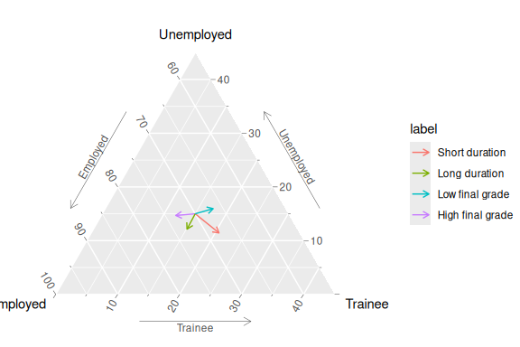

```r
gg3logit(mfields) +
  stat_field3logit(aes(colour = label)) +
  theme_zoom_L(0.45)
```

The code needed for generating the object `mfields` may be conveniently made shorter in this way (see the main vignette of the package or the help of `field3logit` for details on syntax):

```r
depo <- list(
  list(delta = 'durationShort', label = 'Short duration'),
  list(delta = 'durationLong', label = 'Long duration'),
  list(delta = 'finalgradeHigh', label = 'High final grade'),
  list(delta = 'finalgradeLow', label = 'Low final grade')
)

mfields <- field3logit(mod0, delta = depo, p0 = refpoint, narrows = 1)
mfields
```

```
#>  Object of class "multifield3logit"
#> ------------------------------------
#> Number of fields         : 4
#> Labels
#>   1. Short duration    (dX: durationShort)
#>   2. Long duration     (dX: durationLong)
#>   3. High final grade  (dX: finalgradeHigh)
#>   4. Low final grade   (dX: finalgradeLow)
```

It is also possible to rely on syntax based on delimiters `<<...>>` (see the help of `field3logit`, section **Details** or the main vignette of the package) in order to create a `multifield3logit` object consisting of fields based on the effect of each dummy variable generated by the same `factor` regressor:

```r
field3logit(mod0, delta = '<<finalgrade>>', p0 = refpoint, narrows = 1)
```

```
#>  Object of class "multifield3logit"
#> ------------------------------------
#> Number of fields         : 2
#> Labels
#>   1. Low   (dX: `finalgradeLow`)
#>   2. High  (dX: `finalgradeHigh`)
```

## Confidence regions

The package `plot3logit` allows also to draw the confidence regions associated to each effect, both in case of `field3logit` and `multifield3logit` objects.

The confidence regions can be computed when the function `field3logit` is called by setting the argument `conf`. Otherwise, they can be added later through the function `add_confregions` as it follows:

```r
field0 <- add_confregions(field0, conf = 0.95)
field0
```

```
#>  Object of class "field3logit"
#> -------------------------------
#> Label                    : <empty>
#> Possible outcomes        : Employed; Unemployed; Trainee
#> Reference level          : Employed
#> Type of model            : categorical
#> Effect                   : genderFemale
#> Explicit effect          : 0 1 0 0 0 0 0 0 0 0 0 0 0
#> Model has been read from : nnet::multinom
#> Number of stream lines   : 8
#> Number of arrows         : 111
#> Covariance matrix        : available
#> Confidence regions       : 95%
```

and through the same syntax in case of `multifield3logit` objects:

```r
mfields <- add_confregions(mfields, conf = 0.95)
```

The statistic `stat_conf3logit` permits confidence regions to be drawn, if available:

```r
gg3logit(field0) + stat_field3logit() + stat_conf3logit()
```

[output not shown]

and

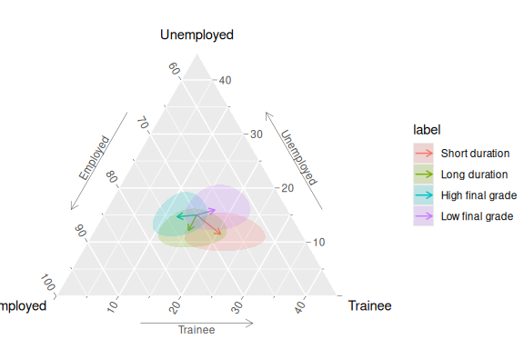

```r
gg3logit(mfields) +
  stat_field3logit(aes(colour = label)) +
  stat_conf3logit(aes(fill = label)) +
  theme_zoom_L(0.45)
```

## References

Christensen, R. H. B. 2019. *ordinal: Regression Models for Ordinal Data*. https://CRAN.R-project.org/package=ordinal.

Croissant, Y. 2020. *mlogit: Multinomial Logit Models*. https://CRAN.R-project.org/package=mlogit.

Hamilton, N. E., and M. Ferry. 2018. “ggtern: Ternary Diagrams Using ggplot2.” *Journal of Statistical Software, Code Snippets* 87 (3): 1–17. https://doi.org/10.18637/jss.v087.c03.

Santi, F., M. M. Dickson, and G. Espa. 2019. “A Graphical Tool for Interpreting Regression Coefficients of Trinomial Logit Models.” *The American Statistician* 73 (2): 200–207. https://doi.org/10.1080/00031305.2018.1442368.

Santi, F., M. M. Dickson, G. Espa, and D. Giuliani. 2022. “plot3logit: Ternary Plots for Interpreting Trinomial Regression Models.” *Journal of Statistical Software, Code Snippets* 103 (1): 1–27. https://doi.org/10.18637/jss.v103.c01.

Smith, M. R. 2017. “Ternary: An R Package for Creating Ternary Plots.” *Zenodo*.

Venables, W. N., and B. D. Ripley. 2002. *Modern Applied Statistics with S*. Fourth. New York: Springer-Verlag. https://www.stats.ox.ac.uk/pub/MASS4/.

Wickham, H. 2016. *ggplot2: Elegant Graphics for Data Analysis*. New York: Springer-Verlag.

Yee, T. W. 2010. “The VGAM Package for Categorical Data Analysis.” *Journal of Statistical Software, Articles* 32 (10): 1–34. https://doi.org/10.18637/jss.v032.i10.